# Supervised Learning and Visualisation

Practical 2

Willem van Veluw

19-9-2022

For this practical we first load the necessary packages.

```r
library(ISLR)
library(tidyverse)
```

### Exercise 1

In the visualisation we see the following.

**Aesthetics:**  
The x-axis shows the number of hits;  
The y-axis shows the number of home runs;  
**Geoms:** the visualisation uses points and contour lines;  
**Scales:** both axes are a continuous scale;  
**Facets** no facets are used;  
**Statistical transformations:** no statistical transformation is applied;  
**Coordinate system:** standard (Cartesian) coordinate system.

### Exercise 2

In this exercise we generate the data frame that will be used for exploring the *ggplot* function. The generation process is shown below.

```r
set.seed(1234)
student_grade <- rnorm(32,7)
student_number <- round(runif(32) * 2e6 + 5e6)
programme <- sample(c("Science", "Social Science"), 32, replace = TRUE)
gg_students <- data.frame(StudentNr = as.character(student_number),
                       Grade = student_grade,
                       Prog = as.factor(programme))
```

### Exercise 3

The code to generate the plot is shown below.

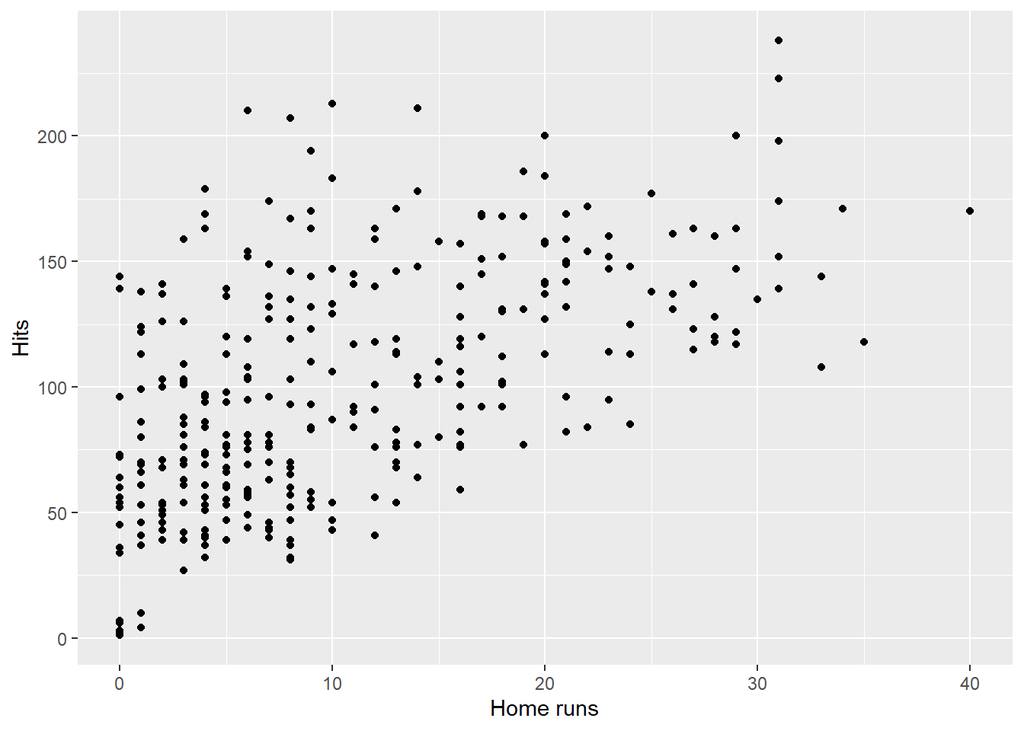

```r
homeruns_plot <-
  ggplot(Hitters, aes(x = HmRun, y = Hits)) +
  geom_point() +
  labs(x = "Home runs", y = "Hits")

homeruns_plot
```

### Exercise 4

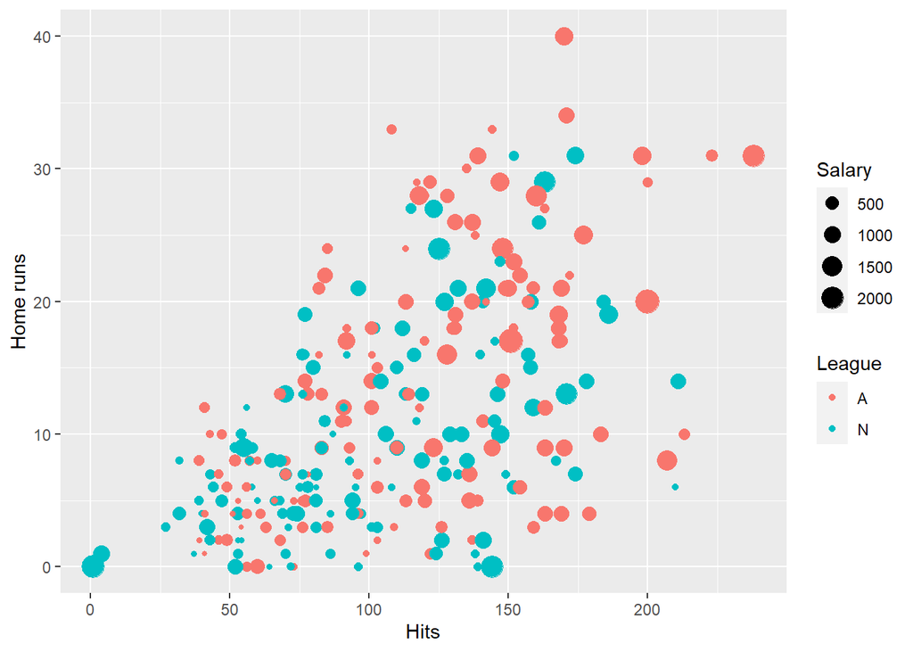

```r
homeruns_ext <-
  Hitters %>% ggplot(aes(x = Hits, y = HmRun, colour = League, size = Salary)) +
  geom_point() +
  labs(x = "Hits", y = "Home runs")

homeruns_ext
```

### Exercise 6

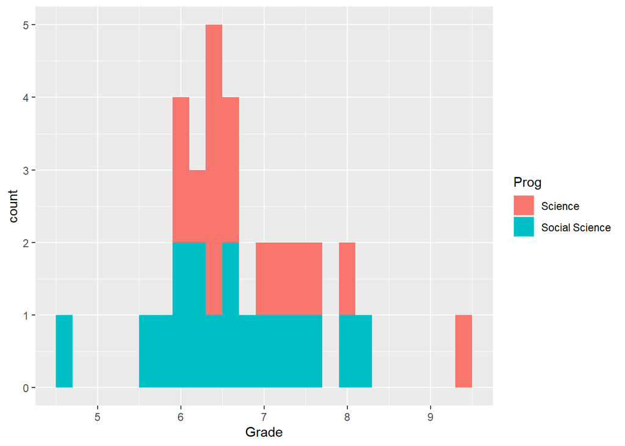

```r
students_hist <-
  gg_students %>% ggplot(aes(x = Grade, fill = Prog)) +
  geom_histogram(binwidth = 0.2)

students_hist
```

### Exercise 7

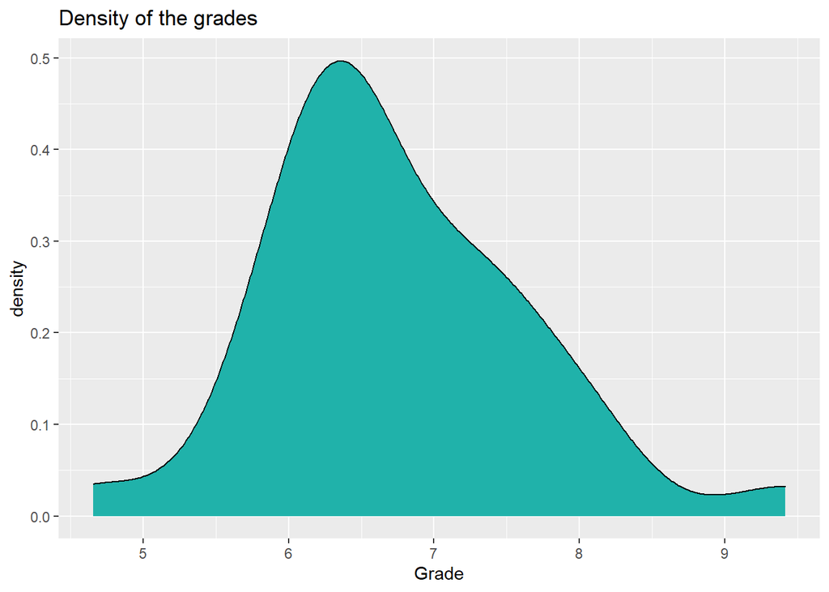

```r
students_dens <-
  gg_students %>% ggplot(aes(x = Grade)) +
  geom_density(fill = "light seagreen") +
  labs(title = "Density of the grades")

students_dens
```

### Exercise 8

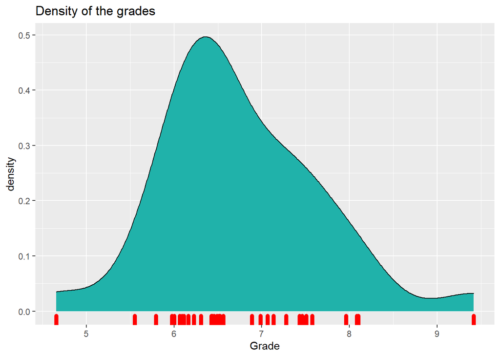

```r
students_dens <-
  students_dens +
  geom_rug(colour = "red", size = 2)

students_dens
```

### Exercise 9

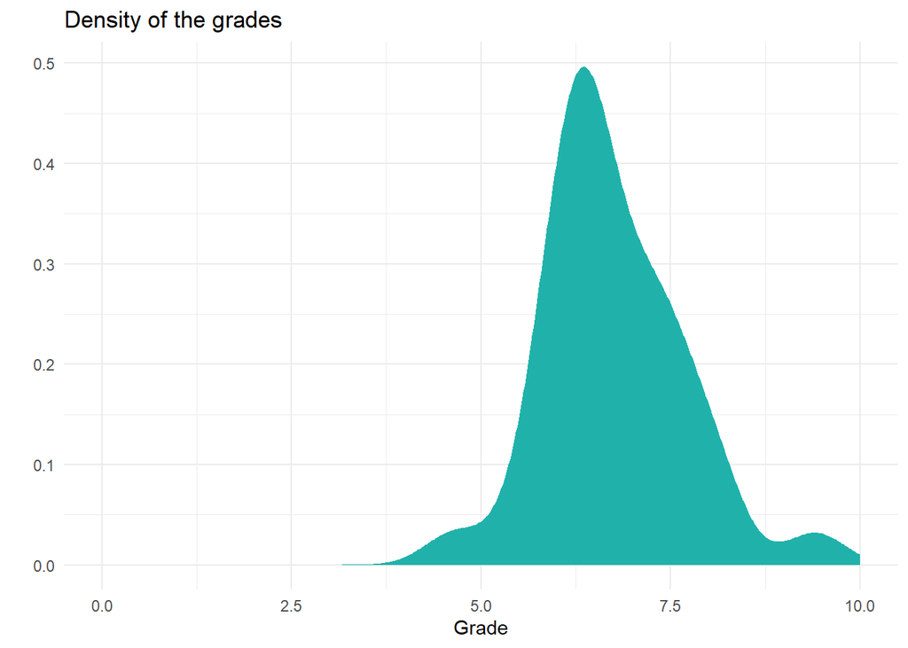

```r
students_dens <-
  gg_students %>% ggplot(aes(x = Grade)) +
  geom_density(fill = "light seagreen", colour = NA) +
  labs(title = "Density of the grades", y = "") +
  xlim(0,10) +
  theme_minimal()


students_dens
```

### Exercise 10

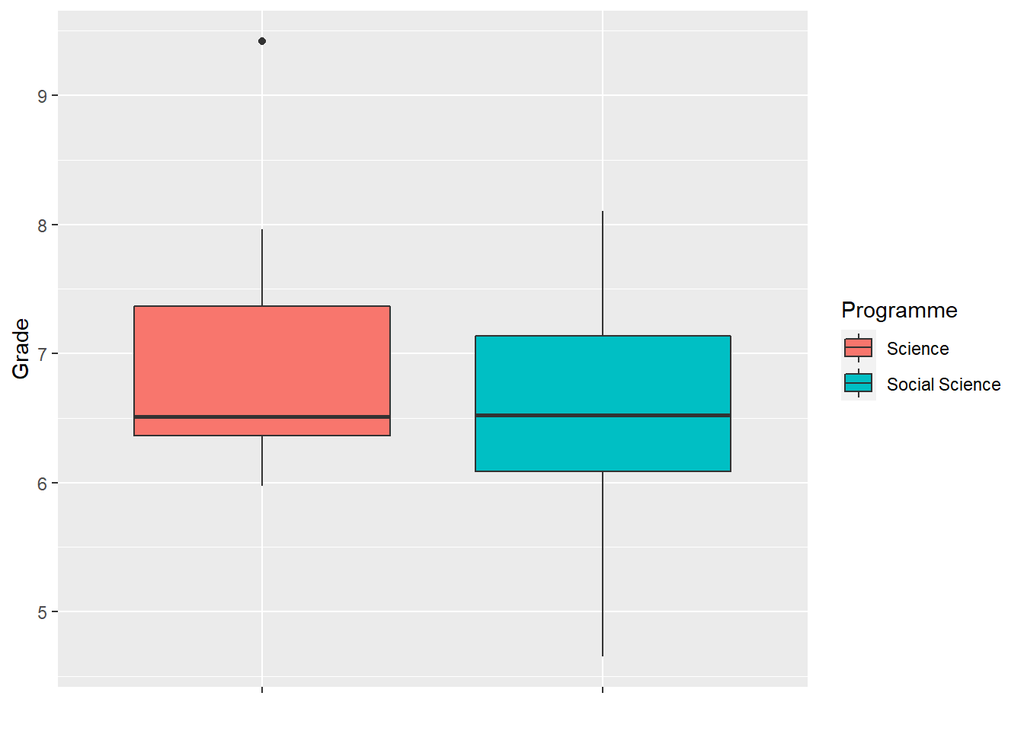

```r
students_box <-
  gg_students %>% ggplot(aes(x = Prog, y = Grade, fill = Prog)) +
  geom_boxplot() +
  labs(x = "", fill = "Programme") +
  theme(axis.text.x = element_blank())

students_box
```

### Exercise 11

The horizontal lines indicate the first quartile, median and third quartile.  
The vertical line on top of the box indicates the largest datapoint in the set that is not more than 1.5$\asterix$IQR away from the third quartile. IQR stands for inter-quartile range. The vertical line on the bottom of the box indicates the largest datapoint in the set that is not less than 1.5$\asterix$IQR away from the first quartile.

### Exercise 12

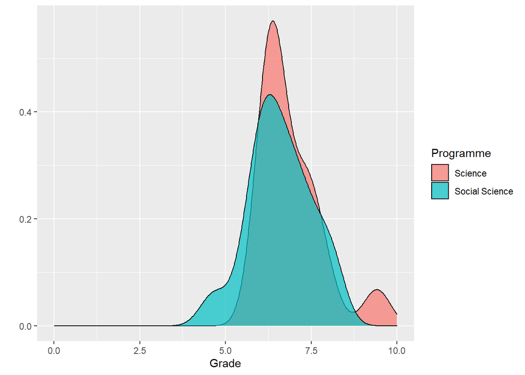

```r
students_dens <-
  gg_students %>% ggplot(aes(x = Grade, fill = Prog)) +
  geom_density(alpha=0.7) +
  xlim(0,10) +
  labs(y = "", fill = "Programme")

students_dens
```

### Exercise 13

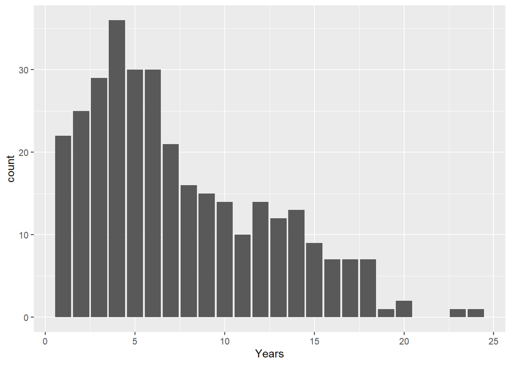

```r
hitters_bar <-
  Hitters %>% ggplot(aes(x = Years)) +
  geom_bar()

hitters_bar
```

### Exercise 14

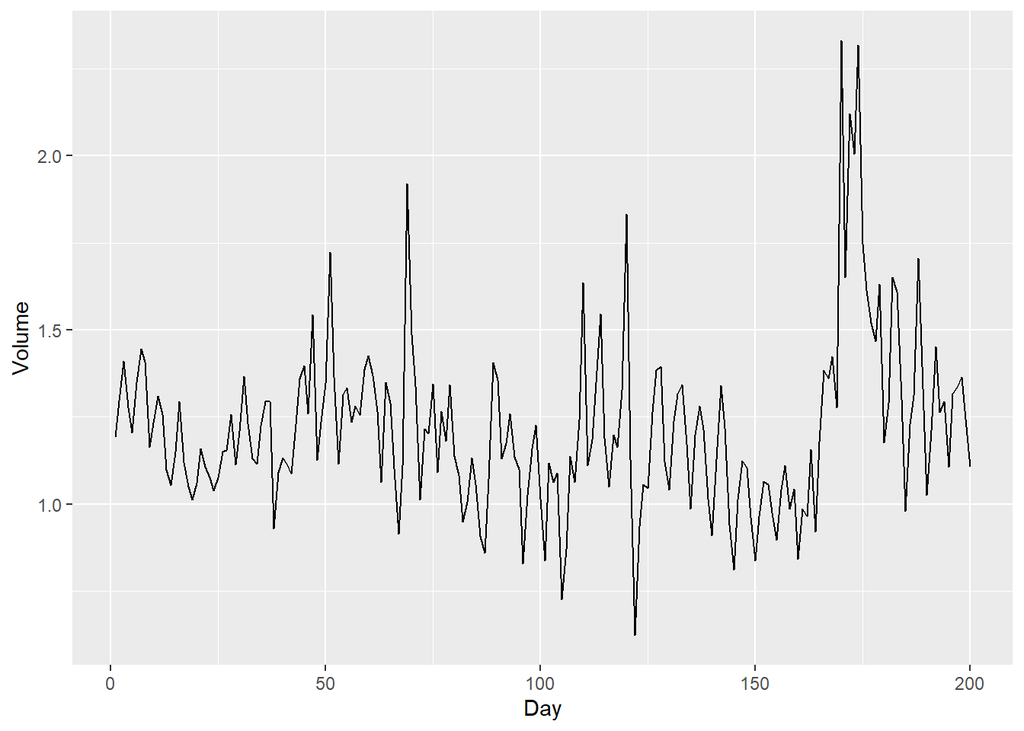

```r
Smarket_data <- Smarket[1:200,] %>% mutate(Day = c(1:200))
Smarket_line <-
  Smarket_data %>% ggplot(aes(x = Day, y = Volume)) +
  geom_line()

Smarket_line
```

### Exercise 15

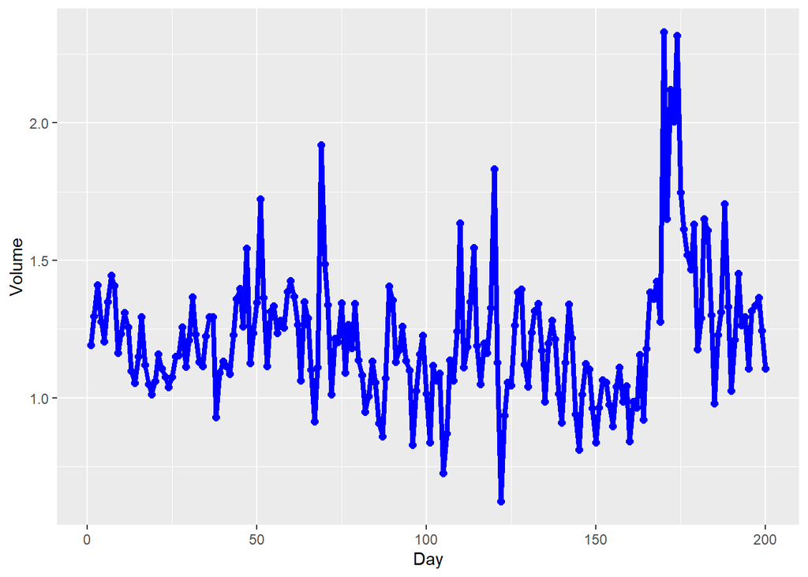

```r
Smarket_data <- Smarket[1:200,] %>% mutate(Day = c(1:200))
Smarket_line <-
  Smarket_data %>% ggplot(aes(x = Day, y = Volume)) +
  geom_line(colour = "blue", size = 1.5) +
  geom_point(colour = "blue", size = 2)

Smarket_line
```

### Exercise 16

The day with the maximal volume is day

```r
which.max(Smarket_data$Volume)
```

```
## [1] 170
```

The volume on that day equaled

```r
max(Smarket_data$Volume)
```

```
## [1] 2.33083
```

### Exercise 17

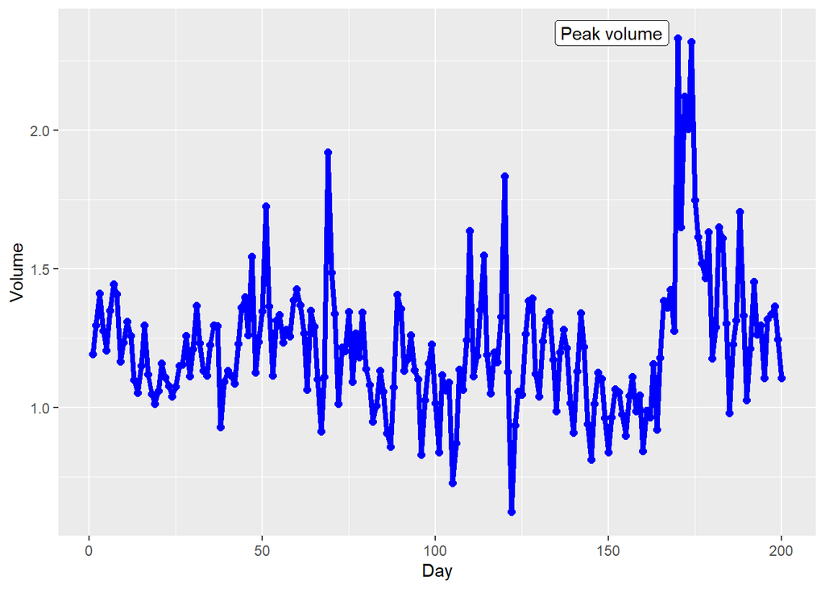

```r
Smarket_line <-
  Smarket_data %>% ggplot(aes(x = Day, y = Volume)) +
  geom_line(colour = "blue", size = 1.5) +
  geom_point(colour = "blue", size = 2) +
  geom_label(aes(x = 170, y = max(Smarket_data$Volume), label = "Peak volume"), nudge_x = -19, nudge_y = 0.02)

Smarket_line
```

### Exercise 18

The three categories that I have created to distribute a player’s Salary are the following:

**Low income** if salary $\leq 500$;  
**Middle income** if $500 <$ salary $\leq 1500$;  
**High income** if salary $\geq 1500$.

```r
baseball <-
  Hitters %>%
  filter(!is.na(Salary)) %>%
  mutate(Income = as.factor(cut(Salary, breaks = c(0,500, 1500,2500), labels = c("Low", "Middle", "High")))) %>%
  mutate(HmRunRate = CHmRun/CHits)
```

### Exercise 19

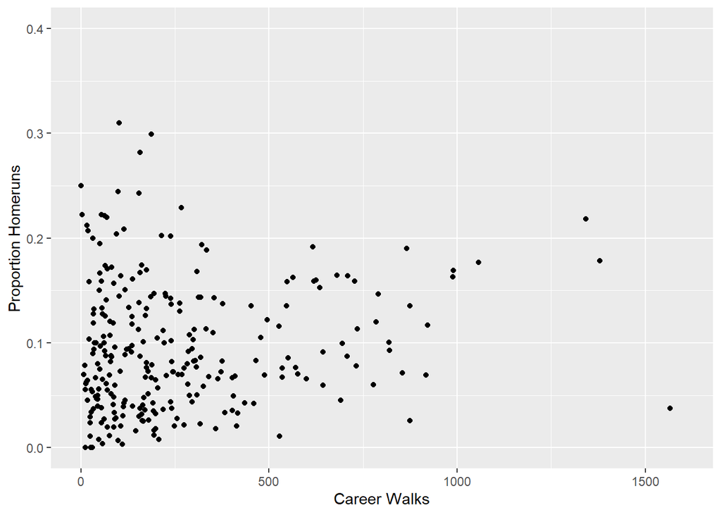

```r
baseball_plot <-
  baseball %>% ggplot(aes(x = CWalks, y = HmRunRate)) +
  geom_point() +
  ylim(0,0.4) +
  xlim(0,1600) +
  labs(x = "Career Walks", y = "Proportion Homeruns")

baseball_plot
```

### Exercise 20

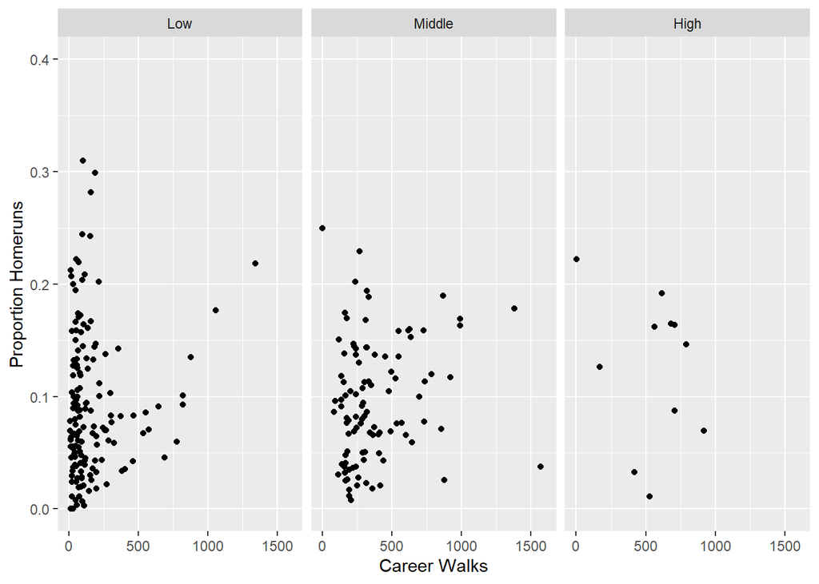

```r
baseball_plot <-
  baseball_plot + facet_wrap(vars(Income))

baseball_plot
```

### Exercise 21

In the following plot we can see the density of the price of a carseat. We have splitted on whether or not a seller is in an urban or rural region. We also distinguished between the quality of the shelving location.

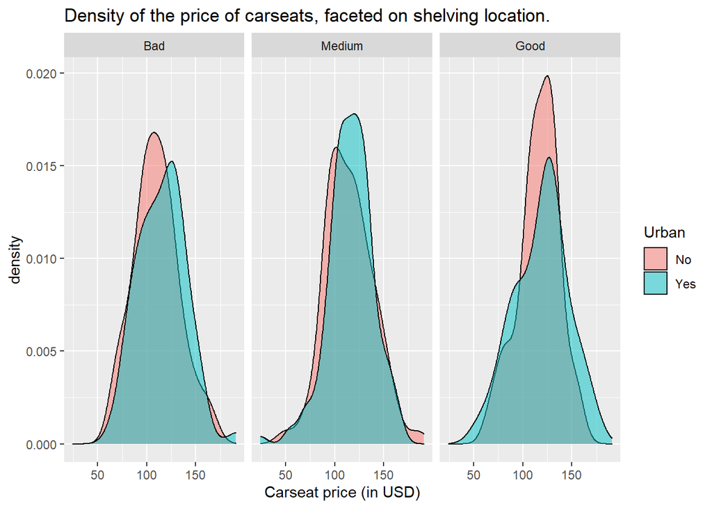

```r
Carseats$ShelveLoc <- fct_relevel(Carseats$ShelveLoc, "Bad", "Medium", "Good")
carseats_plot <-
  Carseats %>% ggplot(aes(x = Price, fill = Urban)) +
  geom_density(alpha = 0.5) +
  facet_wrap(vars(ShelveLoc)) +
  labs(x = "Carseat price (in USD)",
       title = "Density of the price of carseats, faceted on shelving location.")

carseats_plot
```